[figure not shown]

#### Modelos de Regressão para Dados de Contagem com o R

##### [`github.com/leg-ufpr/MRDCr`](https://github.com/leg-ufpr/MRDCr)

# Análise de Contagens Modelando Excesso de Zeros

Walmes M. Zeviani, Eduardo E. Ribeiro Jr & Cesar A. Taconeli

```r
library(MRDCr)
```

# Números de peixes capturados em um Parque Estadual

```r
data(peixe)
peixe$campista <- as.factor(peixe$campista)
levels(peixe$campista) <- c("Não", "Sim")

str(peixe)
```

```
## 'data.frame':    250 obs. of  4 variables:
##  $ campista : Factor w/ 2 levels "Não","Sim": 1 2 1 2 1 2 1 1 2 2 ...
##  $ ncriancas: int  0 0 0 1 0 2 1 3 2 0 ...
##  $ npessoas : int  1 1 1 2 1 4 3 4 3 1 ...
##  $ npeixes  : int  0 0 0 0 1 0 0 0 0 1 ...
```

```r
## help(peixe)
```

Dados sobre 250 grupos que foram ao Parque Estadual para pescar. As informações coletadas foram refentes a presenção ou não de um campista, ao número de crianças no grupo e ao número de indivíduos no grupo. Assim as variáveis definidas são:

`campista`: Fator com dois níveis que representa a presença (*Sim*) ou ausência (*Não*) de um campista no grupo.

`ncriancas`: Número de crianças no grupo.

`npessoas`: Número total de pessoas no grupo.

`npeixes`: Número de peixes capturados pelo grupo.

## Análise exploratória

```r
## Estudo observacional
ftable(with(peixe, table(npessoas, ncriancas, campista)))
```

```
##                    campista Não Sim
## npessoas ncriancas
## 1        0                   22  35
##          1                    0   0
##          2                    0   0
##          3                    0   0
## 2        0                   17  18
##          1                   12  23
##          2                    0   0
##          3                    0   0
## 3        0                    8  13
##          1                    8  11
##          2                    5  12
##          3                    0   0
## 4        0                    6  13
##          1                   10  11
##          2                   11   5
##          3                    4   6
```

```r
## Resumo das variáveis
summary(peixe)
```

```
##  campista    ncriancas        npessoas        npeixes
##  Não:103   Min.   :0.000   Min.   :1.000   Min.   :  0.000
##  Sim:147   1st Qu.:0.000   1st Qu.:2.000   1st Qu.:  0.000
##            Median :0.000   Median :2.000   Median :  0.000
##            Mean   :0.684   Mean   :2.528   Mean   :  3.296
##            3rd Qu.:1.000   3rd Qu.:4.000   3rd Qu.:  2.000
##            Max.   :3.000   Max.   :4.000   Max.   :149.000
```

```r
## Resumo das variáveis, considerando somente as respostas não nulas
summary(subset(peixe, npeixes > 0))
```

```
##  campista   ncriancas         npessoas        npeixes
##  Não:34   Min.   :0.0000   Min.   :1.000   Min.   :  1.00
##  Sim:74   1st Qu.:0.0000   1st Qu.:2.000   1st Qu.:  1.00
##           Median :0.0000   Median :3.000   Median :  3.00
##           Mean   :0.3241   Mean   :2.667   Mean   :  7.63
##           3rd Qu.:1.0000   3rd Qu.:4.000   3rd Qu.:  6.00
##           Max.   :2.0000   Max.   :4.000   Max.   :149.00
```

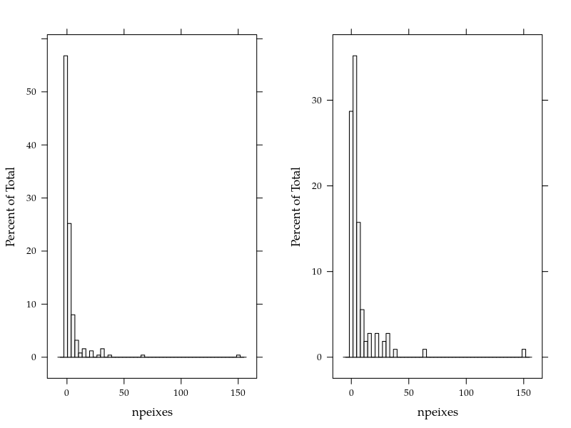

```r
## Contagens (marginal aos efeitos das covariáveis)
p1 <- histogram(~npeixes, data = peixe, nint = 50, grid = TRUE)
p2 <- histogram(~npeixes, data = subset(peixe, npeixes > 0),
                nint = 50)

print(p1, split = c(1, 1, 2, 1), more = TRUE)
print(p2, split = c(2, 1, 2, 1))
```

```r
## Proporção dos valores observados
(proptb <- cbind("Proporção" = prop.table(table(peixe$npeixes)),
                 "N. observ" = table(peixe$npeixes)))
```

```
##     Proporção N. observ
## 0       0.568       142
## 1       0.124        31
## 2       0.080        20
## 3       0.048        12
## 4       0.024         6
## 5       0.040        10
## 6       0.016         4
## 7       0.012         3
## 8       0.008         2
## 9       0.008         2
## 10      0.004         1
## 11      0.004         1
## 13      0.004         1
## 14      0.004         1
## 15      0.008         2
## 16      0.004         1
## 21      0.008         2
## 22      0.004         1
## 29      0.004         1
## 30      0.004         1
## 31      0.004         1
## 32      0.008         2
## 38      0.004         1
## 65      0.004         1
## 149     0.004         1
```

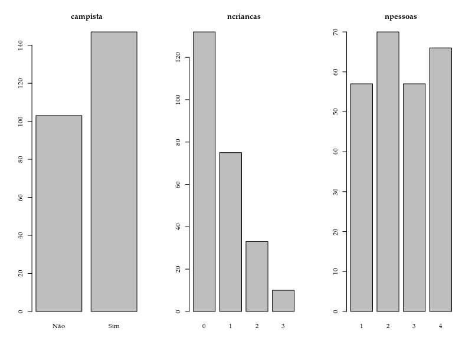

```
## [1] "campista"  "ncriancas" "npessoas"
```

```r
## Disposição das covariáveis
par(mfrow = c(1, 3))
sapply(1:3, function(x) {
    barplot(table(peixe[, x]))
    title(main = names(peixe)[x])
    names(peixe)[x]
})
```

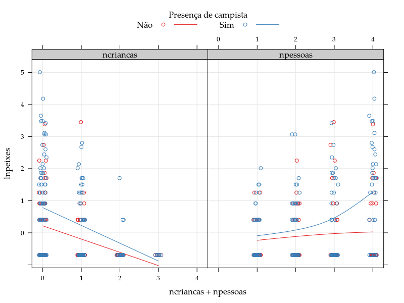

```r
## Contagens com relação as covariáveis
peixe$lnpeixes <- log(peixe$npeixes + 0.5)
xyplot(lnpeixes ~ ncriancas + npessoas,
       groups = campista,
       auto.key = list(
           columns = 2, cex.title = 1, lines = TRUE,
           title = "Presença de campista"),
       data = peixe,
       jitter.x = TRUE,
       type = c("p", "g", "spline"))
```

## Ajuste de modelos

```r
##======================================================================
## Ajuste de modelos hurdle
library(pscl)

## Preditores
f1 <- npeixes ~ campista + npessoas + ncriancas
f2 <- npeixes ~ campista * npessoas + ncriancas

## Poisson
m1P <- glm(f1, data = peixe, family = poisson)
m2P <- glm(f2, data = peixe, family = poisson)

## Hurdle Poisson
m1HP <- hurdle(f1, data = peixe, dist = "poisson")
m2HP <- hurdle(f2, data = peixe, dist = "poisson")

## Zero Inflated Poisson
m1ZP <- zeroinfl(f1, data = peixe, dist = "poisson")
m2ZP <- zeroinfl(f2, data = peixe, dist = "poisson")

## Binomial Negativa
library(MASS)
m1BN <- glm.nb(f1, data = peixe)
m2BN <- glm.nb(f2, data = peixe)

## Hurdle Binomial Negativa
m1HBN <- hurdle(f1, data = peixe, dist = "negbin")
m2HBN <- hurdle(f2, data = peixe, dist = "negbin")

## Zero Inflated Binomial Negativa
m1ZBN <- zeroinfl(f1, data = peixe, dist = "negbin")
m2ZBN <- zeroinfl(f2, data = peixe, dist = "negbin")
```

## Comparação dos ajustes

```r
## Via log-verossimilhança
cbind("Poisson" = sapply(list(m1P, m2P), logLik),
      "HUPoisson" = sapply(list(m1HP, m2HP), logLik),
      "ZIPoisson" = sapply(list(m1ZP, m2ZP), logLik),
      "BinNeg" = sapply(list(m1BN, m2BN), logLik),
      "HUBinNeg" = sapply(list(m1HBN, m2HBN), logLik),
      "ZIBinNeg" = sapply(list(m1ZBN, m2ZBN), logLik)
      )
```

```
##        Poisson HUPoisson ZIPoisson    BinNeg  HUBinNeg  ZIBinNeg
## [1,] -837.0725 -751.6182 -752.7315 -405.2220 -395.1590 -395.5394
## [2,] -830.3639 -743.4591 -744.0157 -404.9135 -393.5848 -394.1446
```

```r
## Testes de razão de verossimilhanças para o efeito de interação
anova(m1BN, m2BN)
```

```
## Likelihood ratio tests of Negative Binomial Models
##
## Response: npeixes
##                             Model     theta Resid. df
## 1 campista + npessoas + ncriancas 0.4635288       246
## 2 campista * npessoas + ncriancas 0.4672296       245
##      2 x log-lik.   Test    df  LR stat.   Pr(Chi)
## 1        -810.444
## 2        -809.827 1 vs 2     1 0.6170103 0.4321604
```

```r
lmtest::lrtest(m1HBN, m2HBN)
```

```
## Likelihood ratio test
##
## Model 1: npeixes ~ campista + npessoas + ncriancas
## Model 2: npeixes ~ campista * npessoas + ncriancas
##   #Df  LogLik Df  Chisq Pr(>Chisq)
## 1   9 -395.16
## 2  11 -393.58  2 3.1484     0.2072
```

```r
lmtest::lrtest(m1ZBN, m2ZBN)
```

```
## Likelihood ratio test
##
## Model 1: npeixes ~ campista + npessoas + ncriancas
## Model 2: npeixes ~ campista * npessoas + ncriancas
##   #Df  LogLik Df  Chisq Pr(>Chisq)
## 1   9 -395.54
## 2  11 -394.14  2 2.7896     0.2479
```

```r
## Teste de Vuong para diferença entre os modelos BN e HUBN
vuong(m1BN, m1HBN)
```

```
## Vuong Non-Nested Hypothesis Test-Statistic:
## (test-statistic is asymptotically distributed N(0,1) under the
##  null that the models are indistinguishible)
## -------------------------------------------------------------
##               Vuong z-statistic             H_A  p-value
## Raw                  -1.5078524 model2 > model1 0.065796
## AIC-corrected        -0.9084884 model2 > model1 0.181810
## BIC-corrected         0.1468301 model1 > model2 0.441633
```

```r
## Teste de Vuong para diferença entre os modelos ZIBN e HUBN
vuong(m1ZBN, m1HBN)
```

```
## Vuong Non-Nested Hypothesis Test-Statistic:
## (test-statistic is asymptotically distributed N(0,1) under the
##  null that the models are indistinguishible)
## -------------------------------------------------------------
##               Vuong z-statistic             H_A p-value
## Raw                 -0.09895803 model2 > model1 0.46059
## AIC-corrected       -0.09895803 model2 > model1 0.46059
## BIC-corrected       -0.09895803 model2 > model1 0.46059
```

```r
## Estimativas dos parâmetros e testes de Wald
summary(m1BN)
```

```
##
## Call:
## glm.nb(formula = f1, data = peixe, init.theta = 0.4635287626,
##     link = log)
##
## Deviance Residuals:
##     Min       1Q   Median       3Q      Max
## -1.6673  -0.9599  -0.6590  -0.0319   4.9433
##
## Coefficients:
##             Estimate Std. Error z value Pr(>|z|)
## (Intercept)  -1.6250     0.3304  -4.918 8.74e-07 ***
## campistaSim   0.6211     0.2348   2.645  0.00816 **
## npessoas      1.0608     0.1144   9.273  < 2e-16 ***
## ncriancas    -1.7805     0.1850  -9.623  < 2e-16 ***
## ---
## Signif. codes:  0 '***' 0.001 '**' 0.01 '*' 0.05 '.' 0.1 ' ' 1
##
## (Dispersion parameter for Negative Binomial(0.4635) family taken to be 1)
##
##     Null deviance: 394.25  on 249  degrees of freedom
## Residual deviance: 210.65  on 246  degrees of freedom
## AIC: 820.44
##
## Number of Fisher Scoring iterations: 1
##
##
##               Theta:  0.4635
##           Std. Err.:  0.0712
##
##  2 x log-likelihood:  -810.4440
```

```r
summary(m1HBN)
```

```
##
## Call:
## hurdle(formula = f1, data = peixe, dist = "negbin")
##
## Pearson residuals:
##      Min       1Q   Median       3Q      Max
## -0.72774 -0.51588 -0.25938 -0.03287 14.70973
##
## Count model coefficients (truncated negbin with log link):
##             Estimate Std. Error z value Pr(>|z|)
## (Intercept)  -1.6215     0.5960  -2.720 0.006521 **
## campistaSim   0.3746     0.3360   1.115 0.264934
## npessoas      1.0029     0.1551   6.465 1.01e-10 ***
## ncriancas    -1.0945     0.3198  -3.422 0.000621 ***
## Log(theta)   -1.0530     0.4974  -2.117 0.034266 *
## Zero hurdle model coefficients (binomial with logit link):
##             Estimate Std. Error z value Pr(>|z|)
## (Intercept)  -2.3087     0.4612  -5.005 5.57e-07 ***
## campistaSim   1.0179     0.3246   3.136  0.00171 **
## npessoas      1.1104     0.1911   5.811 6.19e-09 ***
## ncriancas    -2.1380     0.3107  -6.882 5.90e-12 ***
## ---
## Signif. codes:  0 '***' 0.001 '**' 0.01 '*' 0.05 '.' 0.1 ' ' 1
##
## Theta: count = 0.3489
## Number of iterations in BFGS optimization: 13
## Log-likelihood: -395.2 on 9 Df
```

```r
summary(m1ZBN)
```

```
##
## Call:
## zeroinfl(formula = f1, data = peixe, dist = "negbin")
##
## Pearson residuals:
##      Min       1Q   Median       3Q      Max
## -0.71806 -0.56103 -0.38168  0.04398 16.16367
##
## Count model coefficients (negbin with log link):
##             Estimate Std. Error z value Pr(>|z|)
## (Intercept)  -1.6177     0.3202  -5.052 4.37e-07 ***
## campistaSim   0.3856     0.2461   1.567 0.117128
## npessoas      1.0901     0.1117   9.761  < 2e-16 ***
## ncriancas    -1.2613     0.2473  -5.100 3.40e-07 ***
## Log(theta)   -0.5929     0.1580  -3.753 0.000174 ***
##
## Zero-inflation model coefficients (binomial with logit link):
##             Estimate Std. Error z value Pr(>|z|)
## (Intercept) -11.9920    64.4408  -0.186    0.852
## campistaSim -10.7704    64.3725  -0.167    0.867
## npessoas      0.2902     0.7314   0.397    0.692
## ncriancas    10.9517    64.3569   0.170    0.865
## ---
## Signif. codes:  0 '***' 0.001 '**' 0.01 '*' 0.05 '.' 0.1 ' ' 1
##
## Theta = 0.5527
## Number of iterations in BFGS optimization: 68
## Log-likelihood: -395.5 on 9 Df
```

```r
## Ajuste de preditor do modelo proposto
## Retira o efeito de campista no preditor para as contagens não nula
m3HBN <- hurdle(npeixes ~ npessoas + ncriancas |
                    campista + npessoas + ncriancas,
                data = peixe, dist = "negbin")
lmtest::lrtest(m1HBN, m3HBN)
```

```
## Likelihood ratio test
##
## Model 1: npeixes ~ campista + npessoas + ncriancas
## Model 2: npeixes ~ npessoas + ncriancas | campista + npessoas + ncriancas
##   #Df  LogLik Df  Chisq Pr(>Chisq)
## 1   9 -395.16
## 2   8 -395.75 -1 1.1744     0.2785
```

```r
## Refazendo o teste de Vuong para comparação de modelos BN e HUBN
vuong(m1BN, m3HBN)
```

```
## Vuong Non-Nested Hypothesis Test-Statistic:
## (test-statistic is asymptotically distributed N(0,1) under the
##  null that the models are indistinguishible)
## -------------------------------------------------------------
##               Vuong z-statistic             H_A p-value
## Raw                  -1.2007642 model2 > model1 0.11492
## AIC-corrected        -0.8206083 model2 > model1 0.20593
## BIC-corrected        -0.1512561 model2 > model1 0.43989
```

## Avaliação do modelo proposto

```r
## Uma pequena avaliação dos resíduos
p1 <- xyplot(residuals(m3HBN) ~ fitted(m3HBN),
             type = c("p", "g", "spline"))

p2 <- qqmath(~residuals(m3HBN, type = "pearson"),
             type = c("p", "g"),
             panel = function(x, ...) {
                 panel.qqmathline(x, ...)
                 panel.qqmath(x, ...)
             })

qqsimul <- hnp::hnp(m3HBN, plot = FALSE)
```

```
## Hurdle negative binomial model
```

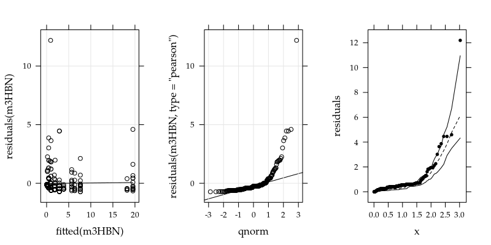

```r
p3 <- with(qqsimul,
           xyplot(residuals ~ x, pch = 20) +
           as.layer(
               xyplot(median + lower + upper ~ x,
                      type = "l", col = 1, lty = c(2, 1, 1)))
           )

print(p1, split = c(1, 1, 3, 1), more = TRUE)
print(p2, split = c(2, 1, 3, 1), more = TRUE)
print(p3, split = c(3, 1, 3, 1), more = FALSE)
```

```r
## Estimativas dos parâmetros e testes de Wald
summary(m3HBN)
```

```
##
## Call:
## hurdle(formula = npeixes ~ npessoas + ncriancas | campista +
##     npessoas + ncriancas, data = peixe, dist = "negbin")
##
## Pearson residuals:
##      Min       1Q   Median       3Q      Max
## -0.72427 -0.49730 -0.25410 -0.01439 12.19296
##
## Count model coefficients (truncated negbin with log link):
##             Estimate Std. Error z value Pr(>|z|)
## (Intercept)  -1.4334     0.5719  -2.506 0.012196 *
## npessoas      1.0260     0.1552   6.612  3.8e-11 ***
## ncriancas    -1.1642     0.3177  -3.665 0.000247 ***
## Log(theta)   -1.1294     0.5185  -2.178 0.029387 *
## Zero hurdle model coefficients (binomial with logit link):
##             Estimate Std. Error z value Pr(>|z|)
## (Intercept)  -2.3087     0.4612  -5.005 5.57e-07 ***
## campistaSim   1.0179     0.3246   3.136  0.00171 **
## npessoas      1.1104     0.1911   5.811 6.19e-09 ***
## ncriancas    -2.1380     0.3107  -6.882 5.90e-12 ***
## ---
## Signif. codes:  0 '***' 0.001 '**' 0.01 '*' 0.05 '.' 0.1 ' ' 1
##
## Theta: count = 0.3232
## Number of iterations in BFGS optimization: 12
## Log-likelihood: -395.7 on 8 Df
```

## Predição

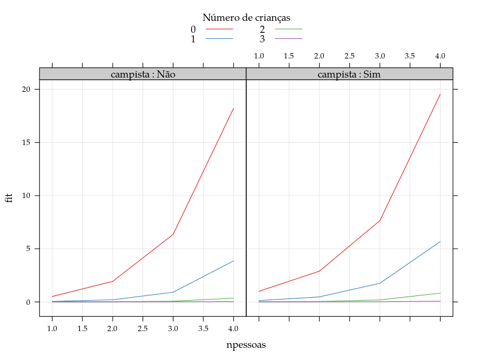

```r
##----------------------------------------------------------------------

## Região para predição
pred <- expand.grid(campista = c("Não", "Sim"),
                    ncriancas = 0:3, npessoas = 1:4)

##-------------------------------------------
## Estimando as médias
aux <- predict(m3HBN, newdata = pred, type = "response")
predmu <- cbind(pred, fit = aux)

xyplot(fit ~ npessoas | campista,
       groups = ncriancas, data = predmu,
       type = c("l", "g"),
       auto.key = list(
           columns = 2, cex.title = 1,
           lines = TRUE, points = FALSE,
           title = "Número de crianças"),
       strip = strip.custom(
           strip.names = TRUE, var.name = "campista"
       ))
```

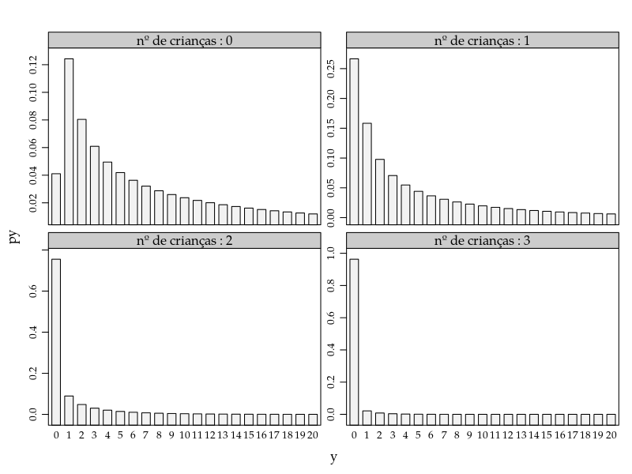

```r
##-------------------------------------------
## Estimando probabilidades
pred <- expand.grid(campista = "Sim",
                    ncriancas = 0:3, npessoas = 4)
py <- c(t(predict(m3HBN, type = "prob", at = 0:20, newdata = pred)))
da <- data.frame(y = 0:20, py = py, ncriancas = rep(0:3, each = 21))

barchart(py ~ y | factor(ncriancas), data = da,
         stack = FALSE, horizontal = FALSE,
         as.table = TRUE, between = list(y = 0.5),
         scales = list( y = "free", x = list(labels = 0:20)),
         strip = strip.custom(
             strip.names = TRUE, var.name = "nº de crianças"
         ))
```

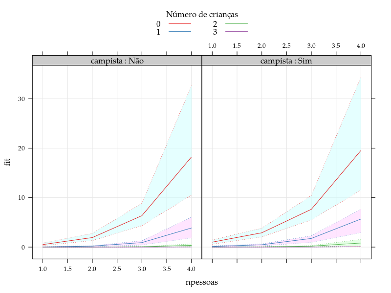

```r
## Intervalos de confiança para predição

##-------------------------------------------
## Via reamostragem
n <- nrow(peixe)
formula <- m3HBN$formula
start <- list(zero = coef(m3HBN, "zero"), count = coef(m3HBN, "count"))

boots <- replicate(100, {
    id <- sample(1:n, replace = TRUE)
    model <- hurdle(formula, data = peixe[id, ], start = start)
    yhat <- predict(model, newdata = predmu, type = "response")
})

pred2 <- cbind(predmu, t(apply(boots, 1, function(x) {
    quantile(x, probs = c(0.025, 0.975))})))
names(pred2)[5:6] <- c("lwr", "upr")

## Viasualizando graficamente
xyplot(fit ~ npessoas | campista,
       groups = ncriancas, data = pred2,
       type = c("l", "g"), cty = "bands",
       ly = pred2$lwr, uy = pred2$upr,
       prepanel = prepanel.cbH, alpha = 0.5,
       panel = panel.superpose,
       panel.groups = panel.cbH,
       auto.key = list(
           columns = 2, cex.title = 1,
           lines = TRUE, points = FALSE,
           title = "Número de crianças"),
       strip = strip.custom(
             strip.names = TRUE, var.name = "campista"
         ))
```

## Ajuste em separado das componentes do modelo Hurdle

```r
## Modelo Hurdle (binomial e binomial negativa)
m3HBN$formula
```

```
## npeixes ~ npessoas + ncriancas | campista + npessoas + ncriancas
```

```r
##-------------------------------------------
## Componente da contagem nula (f_zero)
indica <- with(peixe, ifelse(npeixes == 0, 1, 0))
mzero <- glm(indica ~ campista + npessoas + ncriancas,
             family = binomial, data = peixe)

## Comparando os coeficientes
cbind("glm_binomial" = coef(mzero),
      "zeroinfl" = coef(m3HBN, model = "zero"))
```

```
##             glm_binomial  zeroinfl
## (Intercept)     2.308713 -2.308713
## campistaSim    -1.017853  1.017853
## npessoas       -1.110389  1.110389
## ncriancas       2.137983 -2.137983
```

```r
##-------------------------------------------
## Componente da contagem nula (f_count)
library(VGAM)
countp <- subset(peixe, npeixes > 0)
mcount <- vglm(npeixes ~ npessoas + ncriancas,
               family = posnegbinomial, data = countp)

## Comparando os coeficientes (betas e theta (da BN))
cbind("vglm_posnegbin" = coef(mcount)[-2],
      "zeroinfl" = coef(m3HBN, model = "count"))
```

```
##               vglm_posnegbin  zeroinfl
## (Intercept):1      -1.433280 -1.433370
## npessoas            1.026003  1.026007
## ncriancas          -1.164399 -1.164246
```

```r
cbind("vglm_posnegbin" = exp(coef(mcount)[2]),
      "zeroinfl" = m3HBN$theta)
```

```
##               vglm_posnegbin  zeroinfl
## (Intercept):2      0.3232437 0.3232322
```

# Número de sinistros em uma seguradora de veículos

## Análise exploratória

```r
data(seguros)
str(seguros)
```

```
## 'data.frame':    16483 obs. of  7 variables:
##  $ tipo   : Factor w/ 6 levels "hatch","mono",..: 1 2 5 4 2 1 1 4 5 5 ...
##  $ idade  : int  59 45 42 63 36 33 35 63 54 32 ...
##  $ sexo   : Factor w/ 2 levels "F","M": 1 2 2 1 1 2 2 2 2 2 ...
##  $ civil  : Factor w/ 4 levels "Casado","Divorciado",..: 1 3 1 1 1 1 1 1 1 1 ...
##  $ valor  : num  24.6 23.4 86.6 77.5 25.9 ...
##  $ expos  : num  0.5 0.7 0.79 0.01 0.51 0.79 0.81 0.01 0.76 0.79 ...
##  $ nsinist: int  1 0 0 0 0 0 0 0 0 0 ...
```

```r
## help(seguros)
```

Dados referentes ao acompanhamento de clientes de uma seguradora de automóveis ao longo de um ano. Foram registrados as variáveis descritas abaixo para 16483 clientes.

- `tipo`: Tipo de veículo segurado. Fator com seis níveis (*hatch*, *mono*, *picape*, *sedan*, *wagon* e *suv*).
- `idade`: Idade do cliente, em anos.
- `sexo`: Sexo do cliente. Fator com dois níveis, *M* para clientes do sexo masculino e *F* para feminino.
- `civil`: Estado civil do cliente. Fator com quatro níveis (*Casado*, *Divorciado*, *Solteiro* e *Viuvo*).
- `valor`: Valor do veículo segurado, em 1000 reais.
- `expos`: Período de cobertura do cliente durante o ano sob análise.
- `nsinist`: Número de sinistros registrados no período.

```r
summary(seguros)
```

```
##      tipo          idade       sexo            civil
##  hatch :6080   Min.   :18.00   F:6694   Casado    :13327
##  mono  :1546   1st Qu.:41.00   M:9789   Divorciado:  729
##  picape:1197   Median :52.00            Solteiro  : 1896
##  sedan :4696   Mean   :52.13            Viuvo     :  531
##  suv   :2499   3rd Qu.:62.00
##  wagon : 465   Max.   :96.00
##      valor            expos           nsinist
##  Min.   :  1.60   Min.   :0.0100   Min.   :0.0000
##  1st Qu.: 22.07   1st Qu.:0.5900   1st Qu.:0.0000
##  Median : 31.92   Median :0.7800   Median :0.0000
##  Mean   : 36.03   Mean   :0.6483   Mean   :0.0617
##  3rd Qu.: 45.14   3rd Qu.:0.8100   3rd Qu.:0.0000
##  Max.   :196.65   Max.   :1.0000   Max.   :5.0000
```

## Ajuste de modelos

```r
library(pscl)

## Preditores
f0 <- nsinist ~ 1
f1 <- nsinist ~ sexo + valor + log(expos)
f2 <- nsinist ~ sexo * valor + log(expos)

## Poisson
m0P <- glm(f0, data = seguros, family = poisson)
m1P <- glm(f1, data = seguros, family = poisson)
m2P <- glm(f2, data = seguros, family = poisson)

## Hurdle Poisson
m0HP <- hurdle(f0, data = seguros, dist = "poisson")
m1HP <- hurdle(f1, data = seguros, dist = "poisson")
m2HP <- hurdle(f2, data = seguros, dist = "poisson")

## Zero Inflated Poisson
m0ZP <- zeroinfl(f0, data = seguros, dist = "poisson")
m1ZP <- zeroinfl(f1, data = seguros, dist = "poisson")
m2ZP <- zeroinfl(f2, data = seguros, dist = "poisson")

## Binomial Negativa
library(MASS)
m0BN <- glm.nb(f0, data = seguros)
m1BN <- glm.nb(f1, data = seguros)
m2BN <- glm.nb(f2, data = seguros)

## Hurdle Binomial Negativa
m0HBN <- hurdle(f0, data = seguros, dist = "negbin")
m1HBN <- hurdle(f1, data = seguros, dist = "negbin")
m2HBN <- hurdle(f2, data = seguros, dist = "negbin")

## Zero Inflated Poisson
m0ZBN <- zeroinfl(f0, data = seguros, dist = "negbin")
m1ZBN <- zeroinfl(f1, data = seguros, dist = "negbin")
m2ZBN <- zeroinfl(f2, data = seguros, dist = "negbin")
```